# C_Analyses

André Minder

2023-10-28

# Information about this script

This script contains all preregistered analyses for this project. Note that the raw data was processed in another script (see *B2_processing*). The script includes the following analyses:

- Descriptive statistics of the demographics (gender and age)
- Descriptive statistics of the BART data (exploded balloons per stimulation block, adjusted average pumps)
- Plotting the polarity-specific vestibular effect for the BART
- Descriptive statistics of the GDT data (number of choices per stimulation block, net score)
- Plotting the polarity-specific vestibular effect for the GDT
- Paired t-test for the generic vestibular effect in the BART experiment
- Paired t-test for the specific vestibular effect in the BART experiment
- Equivalence test for the specific vestibular effect (TOST procedure; Lakens, 2017, 2018)
- Exploratory statistics for the BART (Non-parametric test, ANOVA, unpaired t-test)
- Wilcoxon signed-rank test for the generic vestibular effect in the GDT experiment
- Wilcoxon signed-rank test for the specific vestibular effect in the GDT experiment

# Dependencies

```r
library(tidyverse)    # data wrangling
library(janitor)      # for the rounding function round_half_up()
library(easystats)    # easy report of statistics
library(TOSTER)       # for the TOST equivalence testing
library(kableExtra)   # just for printing a nice table in the HTML file
library(effsize)      # used for calculating the critical effect size (see equivalence test)
library(ggpubr)       # for plotting
library(rcompanion)   # get the effect size r for the Wilcoxon signed-rank test
library(mvnormalTest) # test for univariate/multivariate normality
library(car)          # test for homoscedasticity
library(rstatix)      # For ANOVA
library(viridis)      # Color palette for plots
```

# Reading in the data

```r
# reading in the processed data form the B2_processing script
BART_data_processed <- read_csv("processed/BART_data_processed.csv")
GDT_data_processed <- read_csv("processed/GDT_data_processed.csv")
```

# Exclusions

This section excludes participants marked as “excluded” in the processing file (see B2_processing) from the analyses in both data files.

```r
# apply the master exclusion to the BART data
BART_data_processed_after_exclusion <- BART_data_processed |>
  filter(BART_master_exclusions == "include")


# apply the master exclusion to the GDT data
GDT_data_processed_after_exclusion <- GDT_data_processed |>
  filter(GDT_master_exclusions == "include")
```

# Descriptive Statistics

## Demographics

In this section, the descriptive statistics for the relevant gender variables are extracted.

```r
# check if there are excluded participants
BART_data_processed |>
  filter(BART_master_exclusions = FALSE)
```

```
## # A tibble: 0 × 12
## # ℹ 12 variables: subject <chr>, session_BART <chr>, stimulation_BART <chr>,
## #   age <dbl>, gender <chr>, adjusted_mean_pumps <dbl>,
## #   proportion_exploded_balloons <dbl>, n_valid_trials_BART <dbl>,
## #   fast_answer_exclusion_subject <chr>, complete_BART_data <chr>,
## #   duration_all <dbl>, BART_master_exclusions <chr>
```

```r
# Get the descriptive statistics for age and print them in a nice table
BART_data_processed_after_exclusion |>
  mutate(age = as.numeric(age)) |>
  distinct(subject, .keep_all = TRUE) |>
  summarise(Mean = mean(age, na.rm = TRUE),
            SD = sd(age, na.rm = TRUE)) |>
  mutate_all(.funs = janitor::round_half_up, digits = 1) |>
  kable() |>
  add_header_above(header = c("Age" = 2)) |>
  kable_classic(full_width = FALSE)
```

| Age Mean | Age SD |
| --- | --- |
| 22.4 | 2.1 |

```r
# Get the descriptives for gender and also print them in a nice table
BART_data_processed_after_exclusion |>
  rename(Gender = gender) |>
  distinct(subject, .keep_all = TRUE) |>
  group_by(Gender) |>
  summarise(n = n()) |>
  mutate(Percent = paste0(round_half_up((n / sum(n)) * 100, 1), "%")) |>
  mutate(Gender = stringr::str_to_sentence(Gender)) |>
  kable() |>
  kable_classic(full_width = FALSE)
```

| Gender | n | Percent |
| --- | --- | --- |
| Männlich | 8 | 21.6% |
| Weiblich | 29 | 78.4% |

## BART

This section contains generates the descriptive statistics of the BART data. The important variables that are extracted here are the proportion of exploded balloon in each condition as well as the adjusted average pumps for each condition. Additionally, the generic vestibular condition/effect is created in this section (defined as L-GVS + R-GVS / 2).

### Tables

```r
# get the proportion of valid trials

BART_data_processed_after_exclusion |>
  summarize(valid_trials = round_half_up((1 - (sum(n_valid_trials_BART) / (30*37*3)))*100, 2)) |>
  kable() |>
  kable_classic(full_width = FALSE)
```

| valid_trials |
| --- |
| 0.24 |

```r
# extracting the mean proportion of exploded balloons for each stimulation and print it in a nice table
BART_data_processed_after_exclusion |>
  group_by(stimulation_BART) |>
  summarize(proportion_exploded_balloons_mean = round_half_up(mean(proportion_exploded_balloons, na.rm = TRUE), 2),
            proportion_exploded_balloons_sd = round_half_up(sd(proportion_exploded_balloons, na.rm = TRUE), 2)) |>
  kable() |>
  kable_classic(full_width = FALSE)
```

| stimulation_BART | proportion_exploded_balloons_mean | proportion_exploded_balloons_sd |
| --- | --- | --- |
| L-GVS | 0.26 | 0.09 |
| R-GVS | 0.28 | 0.10 |
| SHAM | 0.28 | 0.10 |

```r
# A bit of data wrangling to get the generic vestibular effect (L-GVS + R-GVS / 2)
BART_data_processed_generic_effect <- BART_data_processed_after_exclusion |>
  select("subject", "stimulation_BART", "adjusted_mean_pumps") |>
  pivot_wider(names_from = "stimulation_BART", values_from = "adjusted_mean_pumps") |>
  rowwise() |>
  mutate(generic_effect = sum(`L-GVS`, `R-GVS`, na.rm = TRUE) / 2) |>
  pivot_longer(cols = -subject, names_to = "stimulation_BART", values_to = "adjusted_mean_pumps")

# Get the descriptive statistics for the stimulation effects in a nicely printed table
BART_data_processed_generic_effect |>
  group_by(stimulation_BART) |>
  summarise(Mean = round_half_up(mean(adjusted_mean_pumps), 2),
            SD = round_half_up(sd(adjusted_mean_pumps), 2)) |>
  kable() |>
  kable_classic(full_width = FALSE)
```

| stimulation_BART | Mean | SD |
| --- | --- | --- |
| L-GVS | 30.81 | 10.45 |
| R-GVS | 33.60 | 12.71 |
| SHAM | 33.56 | 12.92 |
| generic_effect | 32.20 | 10.79 |

This section generates a plot to visualize the polarity-specific vestibular effect.

### Plots

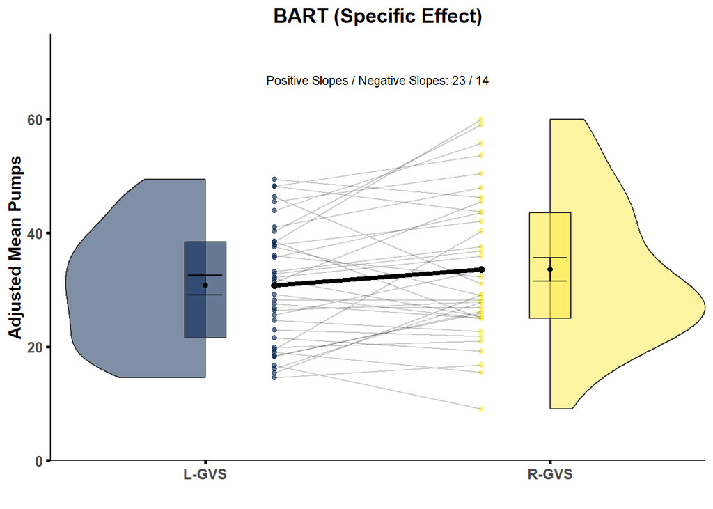

```r
### Plot L-GVS vs. R-GVS (specific effect)

# Calculate the number of positive/negative slopes for the specific effect
n_slopes_BART_spec <- BART_data_processed_after_exclusion |>
  select(subject, stimulation_BART, adjusted_mean_pumps) |>
  pivot_wider(names_from = "stimulation_BART", values_from = "adjusted_mean_pumps") |>
  mutate(slope_positive = ifelse((`R-GVS` - `L-GVS` > 0), TRUE, FALSE)) |>
  summarize(n = sum(slope_positive))

# Plot the data
plot_BART_spec <- BART_data_processed_generic_effect |>
  select(subject, stimulation_BART, adjusted_mean_pumps) |>
  filter(stimulation_BART %in% c("L-GVS", "R-GVS")) |>
  ggplot(aes(x = stimulation_BART, y = adjusted_mean_pumps, fill = stimulation_BART)) +
  introdataviz::geom_split_violin(aes(group = stimulation_BART), alpha = .5) +
  geom_boxplot(aes(group = stimulation_BART), width = .12, fatten = NULL, alpha = .6) +
  geom_point(aes(colour = stimulation_BART), alpha = .6,
              position = position_nudge(x = c(.2, -.2))) +
  geom_line(aes(group = subject), alpha = .2, linewidth = .5,
            position = position_nudge(x = c(.2, -.2))) +
  stat_summary(fun = "mean", geom = "point") +
  stat_summary(fun.data = "mean_se", geom = "errorbar", width = .1) +
  annotate("text", x=1.5, y=67, size = 3,
           label = paste0("Positive Slopes / Negative Slopes: ", n_slopes_BART_spec, " / ",
                          nrow(BART_data_processed_generic_effect)/4 - n_slopes_BART_spec)) +
  coord_cartesian(ylim = c(0, 75), expand = FALSE) +
  stat_summary(fun = "mean", geom = "point", size = 2,
               colour = "black", position = position_nudge(x = c(.2, -.2))) +
  stat_summary(group = 1, fun = "mean", geom = "line", linewidth = 1.5,
               colour = "black", position = position_nudge(x = c(.2, -.2))) +
  xlab("") +
  ylab("Adjusted Mean Pumps") +
  ggtitle("BART (Specific Effect)") +
  theme_classic() +
  theme(plot.title = element_text(size = 14, face = "bold",
                                  hjust = .5),
        axis.ticks = element_line(colour = "black", size = 1),
        axis.text = element_text(face = "bold", size = 10),
        axis.title = element_text(face = "bold", size = 12),
        legend.position = "none") +
  scale_fill_viridis(discrete = TRUE, option = "E") +
  scale_color_viridis(discrete = TRUE, option = "E")

plot_BART_spec
```

```r
ggsave("PolaritySpec_eff_BART.png",
       plot = plot_BART_spec,
       units = "mm",
       width = 90.01,
       dpi = 1000,
       path = "plots")
```

## GDT

In this section, the descriptive statistics for the GDT are calculated. This includes the number of safe/risky choice for each stimulation condition as well as the net score for each stimulation condition. As above, the generic stimulation condition/effect is created in this section too.

### Tables

```r
# Generate a table with the choices per stimulation block
GDT_data_processed_after_exclusion |>
  select("subject", "stimulation_GDT", "safest", "safe", "risky", "riskiest") |>
  pivot_longer(cols = safest:riskiest, names_to = "choice", values_to = "n") |>
  group_by(stimulation_GDT, choice) |>
  summarise(N = sum(n, na.rm = TRUE)) |>
  pivot_wider(names_from = "choice", values_from = "N") |>
  kable() |>
  kable_classic(full_width = FALSE)
```

| stimulation_GDT | riskiest | risky | safe | safest |
| --- | --- | --- | --- | --- |
| L-GVS | 32 | 91 | 201 | 342 |
| R-GVS | 18 | 86 | 254 | 308 |
| SHAM | 15 | 101 | 238 | 312 |

```r
# A bit of data wrangling to get the generic vestibular effect (L-GVS + R-GVS / 2) for the GDT
GDT_data_processed_generic_effect <- GDT_data_processed_after_exclusion |>
  select("subject", "stimulation_GDT", "score") |>
  pivot_wider(names_from = "stimulation_GDT", values_from = "score") |>
  rowwise() |>
  mutate(generic_effect = sum(`L-GVS`, `R-GVS`, na.rm = TRUE) / 2) |>
  pivot_longer(cols = -subject, names_to = "stimulation_GDT", values_to = "score")

# Get the descriptive stats for the stimulation effects in a nicely printed table
GDT_data_processed_generic_effect |>
  group_by(stimulation_GDT) |>
  summarise(Median = round_half_up(median(score), 2),
            MAD = round_half_up(mad(score), 2)) |>
  kable() |>
  kable_classic(full_width = FALSE)
```

| stimulation_GDT | Median | MAD |
| --- | --- | --- |
| L-GVS | -14 | 5.93 |
| R-GVS | -14 | 5.93 |
| SHAM | -14 | 5.93 |
| generic_effect | -14 | 4.45 |

### Plots

This section generates the plot for the polarity-specific vestibular effect in the GDT.

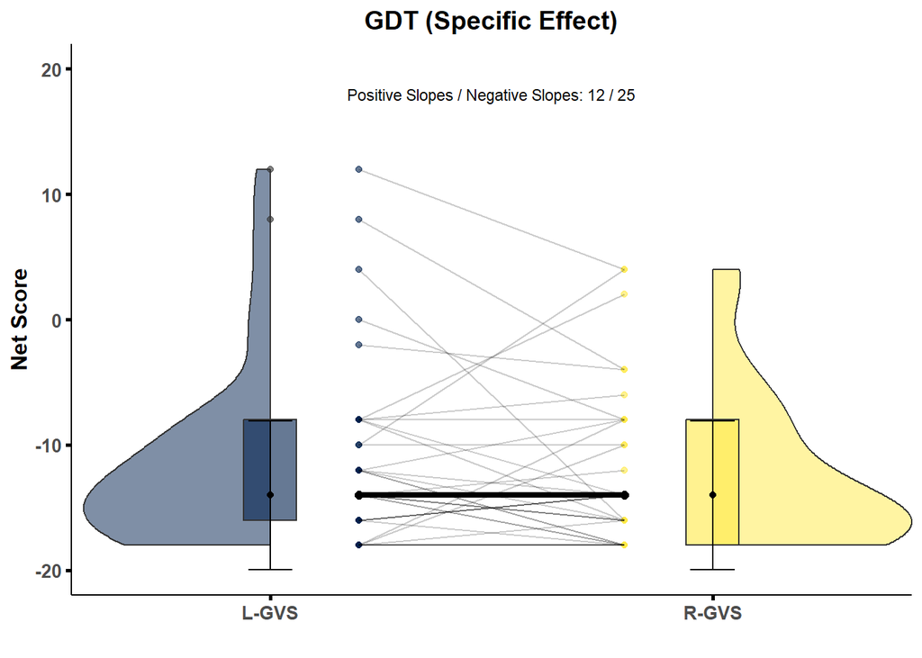

```r
# Specific effect
# Calculate the number of positive/negative slopes for the specific effect
n_slopes_GDT_spec <- GDT_data_processed_after_exclusion |>
  select(subject, stimulation_GDT, score) |>
  pivot_wider(names_from = "stimulation_GDT", values_from = "score") |>
  mutate(slope_positive = ifelse((`R-GVS` - `L-GVS` > 0), TRUE, FALSE)) |>
  summarize(n = sum(slope_positive))

# Plot the data
plot_GDT_spec <- GDT_data_processed_generic_effect |>
  select(subject, stimulation_GDT, score) |>
  filter(stimulation_GDT %in% c("L-GVS", "R-GVS")) |>
  ggplot(aes(x = stimulation_GDT, y = score, fill = stimulation_GDT)) +
  introdataviz::geom_split_violin(aes(group = stimulation_GDT), alpha = .5) +
  geom_boxplot(aes(group = stimulation_GDT), width = .12, fatten = NULL, alpha = .6) +
  geom_point(aes(colour = stimulation_GDT), alpha = .6,
              position = position_nudge(x = c(-.2, .2))) +
  geom_line(aes(group = subject), alpha = .2, linewidth = .5,
            position = position_nudge(x = c(.2, -.2))) +
  stat_summary(fun = "median", geom = "point") +
  stat_summary(fun.data = "median_mad", geom = "errorbar", width = .1) +
  annotate("text", x=1.5, y=18, size = 3,
           label = paste0("Positive Slopes / Negative Slopes: ", n_slopes_GDT_spec, " / ",
                          nrow(GDT_data_processed_generic_effect)/4 - n_slopes_GDT_spec)) +
  coord_cartesian(ylim = c(-22, 22), expand = FALSE) +
  stat_summary(fun = "median", geom = "point", size = 2,
               colour = "black", position = position_nudge(x = c(.2, -.2))) +
  stat_summary(group = 1, fun = "median", geom = "line", linewidth = 1.5,
               colour = "black", position = position_nudge(x = c(.2, -.2))) +
  xlab("") +
  ylab("Net Score") +
  ggtitle("GDT (Specific Effect)") +
  theme_classic() +
  theme(plot.title = element_text(size = 14, face = "bold",
                                  hjust = .5, family = "Helvetica"),
        axis.ticks = element_line(colour = "black", size = 1),
        axis.text = element_text(face = "bold", size = 10, family = "Helvetica"),
        axis.title = element_text(face = "bold", size = 12, family = "Helvetica"),
        legend.position = "none") +
  scale_fill_viridis(discrete = TRUE, option = "E") +
  scale_color_viridis(discrete = TRUE, option = "E")

plot_GDT_spec
```

```r
ggsave("PolaritySpec_eff_GDT.png",
       plot = plot_GDT_spec,
      units = "mm",
       width = 90.01,
       dpi = 1000,
       path = "plots")
```

# Statistical inference

## BART

### T-test BART (generic vestibular effect)

This section contains the t-test for the generic vestibular effect and prints out the detailed results.

```r
# A bit of data wrangling
BART_data_processed_generic_effect_test <- BART_data_processed_generic_effect |>
  filter(stimulation_BART != c("L-GVS", "R-GVS"))

t.test(adjusted_mean_pumps ~ stimulation_BART, data = BART_data_processed_generic_effect_test,
       paired = TRUE, alternative = "two.sided") |>
  report()
```

```
## Effect sizes were labelled following Cohen's (1988) recommendations.
##
## The Paired t-test testing the difference of adjusted_mean_pumps by
## stimulation_BART (mean difference = -1.36) suggests that the effect is
## negative, statistically not significant, and very small (difference = -1.36,
## 95% CI [-4.07, 1.35], t(36) = -1.02, p = 0.315; Cohen's d = -0.17, 95% CI
## [-0.50, 0.16])
```

### T-test BART (specific vestibular effect)

This section contains the t-test for the specific vestibular effect and prints out the detailed results.

```r
# A bit of data wrangling to exclude the SHAM condition
BART_data_processed_specific_effect_test <- BART_data_processed_after_exclusion |>
  filter(stimulation_BART != "SHAM")

t.test(adjusted_mean_pumps ~ stimulation_BART, data = BART_data_processed_specific_effect_test,
       paired = TRUE, alternative = "two.sided") |>
report()
```

```
## Effect sizes were labelled following Cohen's (1988) recommendations.
##
## The Paired t-test testing the difference of adjusted_mean_pumps by
## stimulation_BART (mean difference = -2.79) suggests that the effect is
## negative, statistically not significant, and small (difference = -2.79, 95% CI
## [-5.70, 0.11], t(36) = -1.95, p = 0.059; Cohen's d = -0.32, 95% CI [-0.66,
## 0.01])
```

### Testing the specific vestibular effect for equivalence

This section contains the equivalence test for the specific vestibular effect. THE SESOI is set according to the smallest statistically detectable effect size of the original study (critical effect size; Lakens, 2018). While this kind of test does not directly confirm the absence of a meaningful effect, it allows us to reject effect sizes as large or larger than the critical effect size, thus leading to the conclusion that the effect detected by the original study cannot be as huge as proclaimed.

```r
# get the critical t value of the original study
critical_t <- qt(p = .975, df = 19, lower.tail = TRUE)

# calculate the critical effect size (the effect size that would have just been significant in the original study)
critical_d <- t_to_d(critical_t, df = 19, paired = TRUE, alternative = "two.sided")

t_TOST(
  adjusted_mean_pumps ~ stimulation_BART,
  data = BART_data_processed_specific_effect_test,
  hypothesis = "EQU",
  paired = TRUE,
  rm_correction = TRUE,
  eqb = critical_d$d,
  eqbound_type = "SMD",
  alpha = 0.05,
)
```

```
##
## Paired t-test
##
## The equivalence test was significant, t(36) = 2.05, p = 0.02
## The null hypothesis test was non-significant, t(36) = -1.95p = 0.06
## NHST: don't reject null significance hypothesis that the effect is equal to zero
## TOST: reject null equivalence hypothesis
##
## TOST Results
##                 t df p.value
## t-test     -1.950 36   0.059
## TOST Lower  2.051 36   0.024
## TOST Upper -5.951 36 < 0.001
##
## Effect Sizes
##                Estimate     SE               C.I. Conf. Level
## Raw             -2.7918 1.4319 [-5.2093, -0.3744]         0.9
## Hedges's g(rm)  -0.2291 0.1267  [-0.4959, 0.0409]         0.9
## Note: SMD confidence intervals are an approximation. See vignette("SMD_calcs").
```

### Explorative statistics

#### Non-parameteric testing (Wilcoxon test)

```r
BART_data_processed_specific_effect_test |>
  group_by(stimulation_BART) |>
  summarise(Median = round_half_up(median(adjusted_mean_pumps), 2),
            MAD = round_half_up(mad(adjusted_mean_pumps), 2)) |>
  kable() |>
  kable_classic(full_width = FALSE)
```

| stimulation_BART | Median | MAD |
| --- | --- | --- |
| L-GVS | 31.38 | 12.42 |
| R-GVS | 29.09 | 11.44 |

```r
wilcox.test(adjusted_mean_pumps ~ stimulation_BART, data = BART_data_processed_specific_effect_test,
       paired = TRUE, alternative = "two.sided")
```

```
##
##  Wilcoxon signed rank exact test
##
## data:  adjusted_mean_pumps by stimulation_BART
## V = 232, p-value = 0.07235
## alternative hypothesis: true location shift is not equal to 0
```

```r
wilcoxonPairedR(x = BART_data_processed_specific_effect_test$adjusted_mean_pumps,
                g = BART_data_processed_specific_effect_test$stimulation_BART)
```

```
##      r
## -0.296
```

#### Change Over Time (ANOVA)

##### Testing for normality and homoscedasticity

```r
test_for_norm <- BART_data_processed_after_exclusion |>
  select(subject, adjusted_mean_pumps, session_BART) |>
  pivot_wider(names_from = session_BART, values_from = adjusted_mean_pumps) |>
  select(-subject)

# Test for normality
test_for_norm |>
  mardia(std = TRUE)
```

```
## $mv.test
##           Test Statistic p-value Result
## 1     Skewness    6.0041  0.8149    YES
## 2     Kurtosis   -0.1237  0.9016    YES
## 3 MV Normality      <NA>    <NA>    YES
##
## $uv.shapiro
##    W      p-value UV.Normality
## 01 0.9703 0.4177  Yes
## 02 0.9673 0.3394  Yes
## 03 0.9598 0.1994  Yes
```

```r
# Test for homoscedasticity using the Levene test
leveneTest(adjusted_mean_pumps ~ session_BART, data = BART_data_processed_after_exclusion)
```

```
## Levene's Test for Homogeneity of Variance (center = median)
##        Df F value Pr(>F)
## group   2  1.3068 0.2749
##       108
```

##### Model and post-hoc comparisons

```r
# Calculate one-way repeated-measure ANOVA
aov <- anova_test(
  data = BART_data_processed_after_exclusion,
  dv = adjusted_mean_pumps,
  wid = subject,
  within = session_BART
)

get_anova_table(aov)
```

```
## ANOVA Table (type III tests)
##
##         Effect  DFn   DFd      F        p p<.05   ges
## 1 session_BART 1.53 54.97 18.876 4.44e-06     * 0.068
```

```r
pairwise_t_test(
  data = BART_data_processed_after_exclusion,
  adjusted_mean_pumps ~ session_BART,
  paired = TRUE,
  p.adjust.method = "BH"
)
```

```
## # A tibble: 3 × 10
##   .y.     group1 group2    n1    n2 statistic    df       p   p.adj p.adj.signif
## * <chr>   <chr>  <chr>  <int> <int>     <dbl> <dbl>   <dbl>   <dbl> <chr>
## 1 adjust… 01     02        37    37     -4.26    36 1.41e-4 2.12e-4 ***
## 2 adjust… 01     03        37    37     -4.89    36 2.09e-5 6.27e-5 ****
## 3 adjust… 02     03        37    37     -2.47    36 1.8 e-2 1.8 e-2 *
```

#### Independent t-test

```r
# A bit of data wrangling to exclude the SHAM condition
BART_data_processed_specific_effect_test_block1 <- BART_data_processed_specific_effect_test |>
  filter(session_BART == "01")

BART_data_processed_specific_effect_test_block1 |>
  group_by(stimulation_BART) |>
  summarise(Mean = round_half_up(mean(adjusted_mean_pumps), 2),
            SD = round_half_up(sd(adjusted_mean_pumps), 2)) |>
  kable() |>
  kable_classic(full_width = FALSE)
```

| stimulation_BART | Mean | SD |
| --- | --- | --- |
| L-GVS | 28.14 | 10.15 |
| R-GVS | 28.99 | 8.37 |

```r
t.test(adjusted_mean_pumps ~ stimulation_BART, data = BART_data_processed_specific_effect_test_block1,
       paired = FALSE, alternative = "two.sided") |>
report()
```

```
## Effect sizes were labelled following Cohen's (1988) recommendations.
##
## The Welch Two Sample t-test testing the difference of adjusted_mean_pumps by
## stimulation_BART (mean in group L-GVS = 28.14, mean in group R-GVS = 28.99)
## suggests that the effect is negative, statistically not significant, and very
## small (difference = -0.85, 95% CI [-8.53, 6.82], t(22.73) = -0.23, p = 0.820;
## Cohen's d = -0.10, 95% CI [-0.92, 0.73])
```

#### Correlation Analysis

```r
data_all <-
  full_join(BART_data_processed_after_exclusion, GDT_data_processed_after_exclusion,
            by = c("subject", "age", "gender"))

cor.test(data_all$adjusted_mean_pumps, data_all$score,
         method = "spearman",
         alternative = "two.sided")
```

```
##
##  Spearman's rank correlation rho
##
## data:  data_all$adjusted_mean_pumps and data_all$score
## S = 5692169, p-value = 0.1716
## alternative hypothesis: true rho is not equal to 0
## sample estimates:
##        rho
## 0.07508841
```

## GDT

### Wilcoxon signed-rank test for the GDT score (generic vestibular effect)

This section performs the Wilcoxon test for paired data for the generic vestibular effect in the GDT.

```r
# get rid of the conditions L-GVS and R-GVS
GDT_data_processed_generic_effect_test <- GDT_data_processed_generic_effect |>
  filter(stimulation_GDT != c("L-GVS", "R-GVS"))

# perform the test
wilcox.test(score ~ stimulation_GDT, data = GDT_data_processed_generic_effect_test, paired = TRUE, alternative = "two.sided")
```

```
##
##  Wilcoxon signed rank test with continuity correction
##
## data:  score by stimulation_GDT
## V = 244, p-value = 0.5183
## alternative hypothesis: true location shift is not equal to 0
```

```r
wilcoxonPairedR(x = GDT_data_processed_generic_effect_test$score,
                g = GDT_data_processed_generic_effect_test$stimulation_GDT)
```

```
##      r
## -0.114
```

### Wilcoxon signed-rank test for the GDT score (specific vestibular effect)

This section performs the Wilcoxon test for paired data for the specific vestibular effect in the GDT.

```r
GDT_data_processed_specific_effect_test <- GDT_data_processed_after_exclusion |>
  filter(stimulation_GDT != "SHAM")

wilcox.test(score ~ stimulation_GDT, data = GDT_data_processed_specific_effect_test, paired = TRUE, alternative = "two.sided")
```

```
##
##  Wilcoxon signed rank test with continuity correction
##
## data:  score by stimulation_GDT
## V = 269, p-value = 0.2646
## alternative hypothesis: true location shift is not equal to 0
```

```r
wilcoxonPairedR(x = GDT_data_processed_specific_effect_test$score,
                g = GDT_data_processed_specific_effect_test$stimulation_GDT)
```

```
##    r
## 0.21
```